# R Notebook

Task 1: Import Data and Initial Exploration 1. Import that data into R (using read.table() or read.csv() functions). 2. Print the first 10 rows of the data set (using head() function). 3. Show a summary of all variables using summary() function. 4. Calculate the mean value of medv variable. 5. Plot a histogram of medv variable. Mark the mean value of medv on the plot by adding a vertical line.

```r
# 1.1 import data
df = read.csv("BostonHousing.csv")
class(df)
```

```
[1] "data.frame"
```

```r
# 1.2 print first 10 rows
head(df, 10)
```

|  | crim | zn | indus | chas | nox | rm | age | dis | rad | tax | ptratio | lstat | medv |
| --- | --- | --- | --- | --- | --- | --- | --- | --- | --- | --- | --- | --- | --- |
| 1 | 0.00632 | 18.0 | 2.31 | 0 | 0.538 | 6.575 | 65.2 | 4.0900 | 1 | 296 | 15.3 | 4.98 | 24.0 |
| 2 | 0.02731 | 0.0 | 7.07 | 0 | 0.469 | 6.421 | 78.9 | 4.9671 | 2 | 242 | 17.8 | 9.14 | 21.6 |
| 3 | 0.02729 | 0.0 | 7.07 | 0 | 0.469 | 7.185 | 61.1 | 4.9671 | 2 | 242 | 17.8 | 4.03 | 34.7 |
| 4 | 0.03237 | 0.0 | 2.18 | 0 | 0.458 | 6.998 | 45.8 | 6.0622 | 3 | 222 | 18.7 | 2.94 | 33.4 |
| 5 | 0.06905 | 0.0 | 2.18 | 0 | 0.458 | 7.147 | 54.2 | 6.0622 | 3 | 222 | 18.7 | 5.33 | 36.2 |
| 6 | 0.02985 | 0.0 | 2.18 | 0 | 0.458 | 6.430 | 58.7 | 6.0622 | 3 | 222 | 18.7 | 5.21 | 28.7 |
| 7 | 0.08829 | 12.5 | 7.87 | 0 | 0.524 | 6.012 | 66.6 | 5.5605 | 5 | 311 | 15.2 | 12.43 | 22.9 |
| 8 | 0.14455 | 12.5 | 7.87 | 0 | 0.524 | 6.172 | 96.1 | 5.9505 | 5 | 311 | 15.2 | 19.15 | 27.1 |
| 9 | 0.21124 | 12.5 | 7.87 | 0 | 0.524 | 5.631 | 100.0 | 6.0821 | 5 | 311 | 15.2 | 29.93 | 16.5 |
| 10 | 0.17004 | 12.5 | 7.87 | 0 | 0.524 | 6.004 | 85.9 | 6.5921 | 5 | 311 | 15.2 | 17.10 | 18.9 |

```r
# 1.3 summary() function
summary(df)
```

```
      crim                zn             indus            chas              nox               rm             age              dis              rad
 Min.   : 0.00632   Min.   :  0.00   Min.   : 0.46   Min.   :0.00000   Min.   :0.3850   Min.   :3.561   Min.   :  2.90   Min.   : 1.130   Min.   : 1.000
 1st Qu.: 0.08205   1st Qu.:  0.00   1st Qu.: 5.19   1st Qu.:0.00000   1st Qu.:0.4490   1st Qu.:5.886   1st Qu.: 45.02   1st Qu.: 2.100   1st Qu.: 4.000
 Median : 0.25651   Median :  0.00   Median : 9.69   Median :0.00000   Median :0.5380   Median :6.208   Median : 77.50   Median : 3.207   Median : 5.000
 Mean   : 3.61352   Mean   : 11.36   Mean   :11.14   Mean   :0.06917   Mean   :0.5547   Mean   :6.285   Mean   : 68.57   Mean   : 3.795   Mean   : 9.549
 3rd Qu.: 3.67708   3rd Qu.: 12.50   3rd Qu.:18.10   3rd Qu.:0.00000   3rd Qu.:0.6240   3rd Qu.:6.623   3rd Qu.: 94.08   3rd Qu.: 5.188   3rd Qu.:24.000
 Max.   :88.97620   Max.   :100.00   Max.   :27.74   Max.   :1.00000   Max.   :0.8710   Max.   :8.780   Max.   :100.00   Max.   :12.127   Max.   :24.000
      tax           ptratio          lstat            medv
 Min.   :187.0   Min.   :12.60   Min.   : 1.73   Min.   : 5.00
 1st Qu.:279.0   1st Qu.:17.40   1st Qu.: 6.95   1st Qu.:17.02
 Median :330.0   Median :19.05   Median :11.36   Median :21.20
 Mean   :408.2   Mean   :18.46   Mean   :12.65   Mean   :22.53
 3rd Qu.:666.0   3rd Qu.:20.20   3rd Qu.:16.95   3rd Qu.:25.00
 Max.   :711.0   Max.   :22.00   Max.   :37.97   Max.   :50.00
```

```r
# 1.4 calculate mean of medv
mean(df$medv)
```

```
[1] 22.53281
```

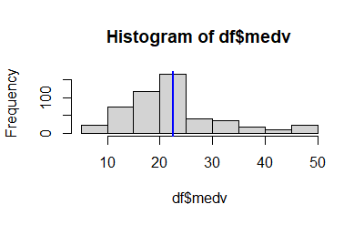

```r
# 1.5 plot histogram of medv
mean_medv = mean(df$medv)
hist(df$medv)
abline(v = mean_medv, col = "blue", lwd = 2)
```

Task 2: Create a Variable 6. Create a variable called cat.medv and add to the data frame. It is a categorical variable whose value equals 1 if the medv value for a tract is greater than $30,000 and equals 0 otherwise. 7. Calculate the mean of cat.medv. Explain what this mean value means.

```r
# 2.6 create new variable cat.medv
df$cat.medv = ifelse(df$medv > 30, 1, 0)
```

```r
# 2.7 mean of cat.medv
mean(df$cat.medv)
```

```
[1] 0.1660079
```

Task 3: Bar Chart Bar charts are useful tools for comparing certain statistics across different groups (or categories). Let’s create a bar chart to compare the average value of cat.medv for the tracts that bound Charles River and that for those tracts that don’t bound the river. Follow the following steps. 8. Calculate the mean of cat.medv for the tracts that bound Charles River (i.e., chas==1), and save it to a variable. 9. Calculate the mean of cat.medv for the tracts that don’t bound Charles River (i.e., chas==0), and save it to a variable. 10. Create a vector that comprises the two calculated mean values. 11. Plot a bar chart using the above created vector as the data. Label the two bars properly (Hint: using the names.arg argument). 12. Discuss what you can tell from the bar chart.

```r
# 3.8 mean of cat.medv where chas==1
mean_cat.medv_chas1 = mean(df$cat.medv[df$chas==1])
mean_cat.medv_chas1
```

```
[1] 0.3142857
```

```r
# 3.9 mean of cat.medv where chas==0
mean_cat.medv_chas0 = mean(df$cat.medv[df$chas==0])
mean_cat.medv_chas0
```

```
[1] 0.1549894
```

```r
# 3.10 create vector
avg0_avg1 = c(mean_cat.medv_chas0, mean_cat.medv_chas1)
avg0_avg1
```

```
[1] 0.1549894 0.3142857
```

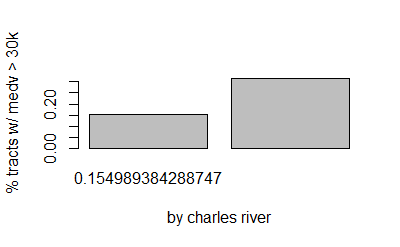

```r
# 3.11 create bar chart
barplot(avg0_avg1, xlab = "by charles river", ylab = "% tracts w/ medv > 30k", names.arg = avg0_avg1)
```

Task 4: Boxplot Boxplots show the distribution of a numerical variable. Side-by-side boxplots allow us to compare such distributions across different groups.

13. Create a side-by-side boxplot of medv over chas, that is, show the distributions of medv for the two groups with chas==1 and chas==0. (Hint: use the ~ operator.) Discuss what you can conclude from the boxplot.

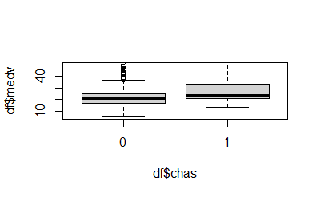

```r
# 4.13 create a boxplot
boxplot(df$medv~df$chas)
```

```r
#
plot(df$lstat, df$medv, xlab="lstat", ylab="medv")
```

[output not shown]

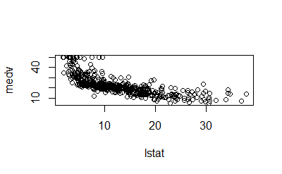

```r
#
plot(df$lstat, df$medv, xlab="lstat", ylab="medv")
```